# SXH

Author

Hoang Quoc Cuong

Published

January 27, 2026

# 1 **DỮ LIỆU SXH**

Báo cáo được cập nhập vào lúc **2026-01-27 21:50:37 | Dữ liệu SXH 2025**

Bản đồ Cần Thơ (thông tin chi tiết phường, xã mới) [**click here**](https://tuhocr.github.io/canthosxh/mapcantho.html)

**Để copy file ảnh đồ thị full-size, ta right-click lên hình, chọn `Open image in new tab`**

# 2 **KIỂM TRA DỮ LIỆU**

**Nhập dữ liệu sai lệch năm (vd file 2025 nhưng lại có bệnh nhân của năm 2026)**

**`Dữ liệu nhập lệch năm`**

```
Dữ liệu ban đầu: 5567
Dữ liệu sau khi lọc theo năm: 5526
Dữ liệu nhập lệch năm: 41
                    TTYTKV PHUONG_XA_MOI    NGAY_VV TUOI NGUOI_NHAP_LIEU NGAY_NHAP_LIEU
2825      TTYT KV Thới Lai     Thạnh Phú 2026-01-02   40     CDC Cần Thơ     2026-01-13
2826      TTYT KV Cái Răng       Nhơn Ái 2026-01-04   34     CDC Cần Thơ     2026-01-13
2827      TTYT KV Cái Răng    Phong Điền 2026-01-03   34     CDC Cần Thơ     2026-01-13
2828      TTYT KV Cái Răng    Phong Điền 2026-01-03    8     CDC Cần Thơ     2026-01-13
2829      TTYT KV Cái Răng   Trường Long 2026-01-04   13     CDC Cần Thơ     2026-01-13
2830     TTYT KV Bình Thủy     Bình Thủy 2026-01-03   50     CDC Cần Thơ     2026-01-13
2831     TTYT KV Bình Thủy  Thới An Đông 2026-01-02   41     CDC Cần Thơ     2026-01-13
2832     TTYT KV Bình Thủy       An Bình 2026-01-02   28     CDC Cần Thơ     2026-01-13
2833     TTYT KV Bình Thủy       An Bình 2026-01-03   13     CDC Cần Thơ     2026-01-13
2835     TTYT KV Bình Thủy        Tân An 2026-01-04   24     CDC Cần Thơ     2026-01-13
2836     TTYT KV Bình Thủy       Cái Khế 2026-01-03    2     CDC Cần Thơ     2026-01-13
```

[output cut: 30 more lines]

**Nếu tổng số `TTYTKV` không vượt quá 22 (năm 2025) hay 20 (năm 2026) thì dữ liệu chính xác.**

**Tổng số TTYTKV là 22**

**`TTYTKV`**

```
    TTYT KV Bình Thủy      TTYT KV Cái Răng  TTYT KV Châu Thành A TTYT KV Châu Thành HG TTYT KV Châu Thành ST   TTYT KV Cù Lao Dung
                 1529                   496                   126                   171                   170                   108
      TTYT KV Kế Sách       TTYT KV Long Mỹ      TTYT KV Long Phú         TTYT KV Mỹ Tú      TTYT KV Mỹ Xuyên       TTYT KV Ngã Năm
                  365                    32                   192                    99                   144                   104
        TTYT KV Ô Môn    TTYT KV Phụng Hiệp     TTYT KV Thạnh Trị      TTYT KV Thới Lai      TTYT KV Thốt Nốt  TTYT KV TP Sóc Trăng
                  271                   229                    49                   258                   202                   308
      TTYT KV Trần Đề       TTYT KV Vị Thủy     TTYT KV Vĩnh Châu    TTYT KV Vĩnh Thạnh
                  401                    71                   116                    85
Tổng số TTYTKV là 22
```

**Nếu tổng số `PHUONG_XA_MOI` không vượt quá 103 thì dữ liệu chính xác.**

**Tổng số PHUONG_XA_MOI là 103**

**`PHUONG_XA_MOI`**

```
        An Bình     An Lạc Thôn         An Ninh        An Thạnh       Bình Thủy         Cái Khế        Cái Răng      Châu Thành
            212             101              78              48             311             152             116              54
          Cờ Đỏ     Cù Lao Dung         Đại Hải        Đại Ngãi       Đại Thành       Đông Hiệp      Đông Phước      Đông Thuận
             32              60              34              32              45              21              21              25
        Gia Hòa       Hiệp Hưng     Hồ Đắc Kiện          Hòa An         Hỏa Lựu          Hòa Tú        Hưng Phú         Kế Sách
             10              33              20              10               6              15             122             106
      Khánh Hòa         Lai Hòa         Lâm Tân Lịch Hội Thượng         Liêu Tú       Long Bình       Long Hưng         Long Mỹ
             21              10              22             115             130              12              12              11
       Long Phú      Long Phú 1      Long Tuyền       Lương Tâm        Mỹ Hương        Mỹ Phước         Mỹ Quới           Mỹ Tú
             79               2             124               3              52               8              32              27
       Mỹ Xuyên         Ngã Bảy         Ngã Năm         Ngọc Tố         Nhơn Ái         Nhơn Mỹ         Nhu Gia       Ninh Kiều
             55              34              50              75             111              50              44             238
          Ô Môn      Phong Điền       Phong Nẫm         Phú Hữu         Phú Lộc         Phú Lợi         Phú Tâm      Phụng Hiệp
             87             109              10              96              22             127              41              23
     Phước Thới     Phương Bình       Sóc Trăng         Tài Văn          Tân An        Tân Bình         Tân Hòa         Tân Lộc
             95               8             126              47             322               9              42              31
       Tân Long  Tân Phước Hưng       Tân Thạnh        Thạnh An       Thạnh Hòa       Thạnh Phú      Thạnh Quới   Thạnh Thới An
             22              13              34               7              54              19              24              31
     Thạnh Xuân    Thới An Đông     Thới An Hội       Thới Hưng        Thới Lai       Thới Long        Thốt Nốt       Thuận Hòa
             73             170              64              13              40              89              67              31
     Thuận Hưng         Trần Đề      Trung Hưng      Trung Nhứt    Trường Khánh     Trường Long Trường Long Tây    Trường Thành
             71              78              37              33              47              38              11              38
    Trường Xuân          Vị Tân        Vị Thanh      Vị Thanh 1         Vị Thủy       Vĩnh Châu        Vĩnh Hải        Vĩnh Lợi
             33              23              23               5               8              46              15               5
     Vĩnh Phước      Vĩnh Thạnh Vĩnh Thuận Đông      Vĩnh Trinh      Vĩnh Tường       Vĩnh Viễn        Xà Phiên
             24              27               4              27               2               3               1
Tổng số PHUONG_XA_MOI là 103
```

**Nếu kết quả tổng số ca theo `TTYTKV` và `PHUONG_XA_MOI` không vượt quá 103 thì dữ liệu chính xác.**

Số liệu này thể hiện bao nhiều phường xã có ca bệnh tương ứng với trung tâm y tế khu vực, tổng số không vượt qua 103 phường xã. Cần kiểm tra xem 1 phường xã có bị trùng ở các trung tâm y tế khu vực khác nhau không.

**Dữ liệu bị trùng**

```
        An Bình     An Lạc Thôn         An Ninh        An Thạnh       Bình Thủy         Cái Khế        Cái Răng      Châu Thành
              1               1               1               1               1               1               1               1
          Cờ Đỏ     Cù Lao Dung         Đại Hải        Đại Ngãi       Đại Thành       Đông Hiệp      Đông Phước      Đông Thuận
              1               1               1               1               1               1               1               1
        Gia Hòa       Hiệp Hưng     Hồ Đắc Kiện          Hòa An         Hỏa Lựu          Hòa Tú        Hưng Phú         Kế Sách
              1               1               1               1               1               1               1               1
      Khánh Hòa         Lai Hòa         Lâm Tân Lịch Hội Thượng         Liêu Tú       Long Bình       Long Hưng         Long Mỹ
              1               1               1               1               1               1               1               1
       Long Phú      Long Phú 1      Long Tuyền       Lương Tâm        Mỹ Hương        Mỹ Phước         Mỹ Quới           Mỹ Tú
              1               1               1               1               1               1               1               1
       Mỹ Xuyên         Ngã Bảy         Ngã Năm         Ngọc Tố         Nhơn Ái         Nhơn Mỹ         Nhu Gia       Ninh Kiều
              1               1               1               1               1               1               1               1
          Ô Môn      Phong Điền       Phong Nẫm         Phú Hữu         Phú Lộc         Phú Lợi         Phú Tâm      Phụng Hiệp
              1               1               1               1               1               1               1               1
     Phước Thới     Phương Bình       Sóc Trăng         Tài Văn          Tân An        Tân Bình         Tân Hòa         Tân Lộc
              1               1               1               1               1               1               1               1
       Tân Long  Tân Phước Hưng       Tân Thạnh        Thạnh An       Thạnh Hòa       Thạnh Phú      Thạnh Quới   Thạnh Thới An
              1               1               1               1               1               1               1               1
     Thạnh Xuân    Thới An Đông     Thới An Hội       Thới Hưng        Thới Lai       Thới Long        Thốt Nốt       Thuận Hòa
              1               1               1               1               1               1               1               1
     Thuận Hưng         Trần Đề      Trung Hưng      Trung Nhứt    Trường Khánh     Trường Long Trường Long Tây    Trường Thành
              1               1               1               1               1               1               1               1
    Trường Xuân          Vị Tân        Vị Thanh      Vị Thanh 1         Vị Thủy       Vĩnh Châu        Vĩnh Hải        Vĩnh Lợi
              1               1               1               1               1               1               1               1
     Vĩnh Phước      Vĩnh Thạnh Vĩnh Thuận Đông      Vĩnh Trinh      Vĩnh Tường       Vĩnh Viễn        Xà Phiên
              1               1               1               1               1               1               1
Tổng số PHUONG_XA_MOI là 103
[1] TTYTKV        PHUONG_XA_MOI TONG_SO_CA
<0 rows> (or 0-length row.names)
```

# 3 **SỐ CA THEO NGÀY [DỮ LIỆU GỐC]**

| TTYTKV | PHUONG_XA_MOI | NGAY_VV | TUOI | PHAN_DO | GHI_CHU | NGUOI_NHAP_LIEU |
| --- | --- | --- | --- | --- | --- | --- |
| TTYT KV Bình Thủy | Long Tuyền | 2025-01-02 | 15 | A97.0 | BVNĐ Cần Thơ | CDC Cần Thơ |
| TTYT KV Bình Thủy | Bình Thủy | 2025-01-01 | 14 | A97.0 | BVNĐ Cần Thơ | CDC Cần Thơ |
| TTYT KV Bình Thủy | Tân An | 2025-01-01 | 7 | A97.0 | BVNĐ Cần Thơ | CDC Cần Thơ |
| TTYT KV Ô Môn | Ô Môn | 2025-01-02 | 28 | A97.0 | BVĐK Tâm Minh Đức | CDC Cần Thơ |
| TTYT KV Ô Môn | Thới Long | 2025-01-02 | 8 | A97.0 | BVNĐ Cần Thơ | CDC Cần Thơ |
| TTYT KV Cái Răng | Phong Điền | 2025-01-01 | 12 | A97.0 | BVNĐ Cần Thơ | CDC Cần Thơ |
| TTYT KV Thới Lai | Đông Thuận | 2025-01-01 | 30 | A97.0 | BV QDY CỜ ĐỎ | CDC Cần Thơ |
| TTYT KV Vĩnh Thạnh | Vĩnh Thạnh | 2025-01-04 | 6 | A97.0 | BVĐK Vĩnh Thạnh | CDC Cần Thơ |
| TTYT KV Bình Thủy | Ninh Kiều | 2025-01-03 | 29 | A97.0 | BV Hòa Hảo - Medic Cần Thơ | CDC Cần Thơ |
| TTYT KV Ô Môn | Thới Long | 2025-01-05 | 2 | A97.0 | BVNĐ Cần Thơ | CDC Cần Thơ |

[output cut: 5516 more lines]

# 4 **TỔNG SỐ CA TRONG NĂM THEO KHU VỰC**

**Từ ngày 2025-01-01 đến ngày 2025-12-31**

**Tổng số ca: 5526 | Tổng số TTYT KV: 22 | Tổng số phường, xã: 103**

**Tổng số phường, xã có ca SXH: 103**

| TTYTKV | Phường, xã mới | Tổng số ca |
| --- | --- | --- |
| TTYT KV Bình Thủy | Tân An | 322 |
| TTYT KV Bình Thủy | Bình Thủy | 311 |
| TTYT KV Bình Thủy | Ninh Kiều | 238 |
| TTYT KV Bình Thủy | An Bình | 212 |
| TTYT KV Bình Thủy | Thới An Đông | 170 |
| TTYT KV Bình Thủy | Cái Khế | 152 |
| TTYT KV Bình Thủy | Long Tuyền | 124 |
| TTYT KV Châu Thành A | Thạnh Xuân | 73 |
| TTYT KV Châu Thành A | Tân Hòa | 42 |
| TTYT KV Châu Thành A | Trường Long Tây | 11 |

[output cut: 93 more lines]

# 5 **ĐỒ THỊ TỔNG SỐ CA THEO KHU VỰC**

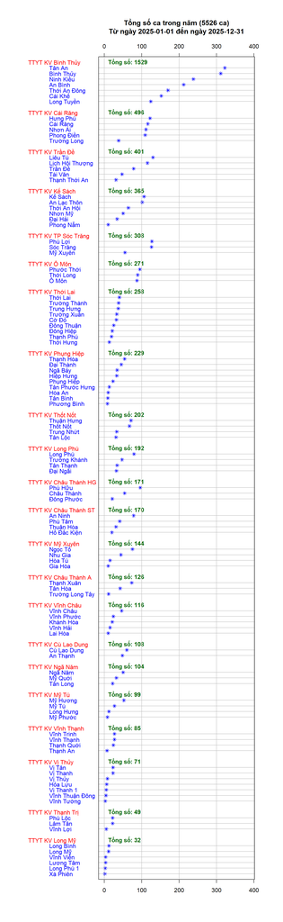

# 6 **TỔNG SỐ CA THEO THÁNG**

| TTYTKV | Phường, xã mới | Tháng | Tổng số ca |
| --- | --- | --- | --- |
| TTYT KV Bình Thủy | An Bình | 1 | 2 |
| TTYT KV Kế Sách | An Lạc Thôn | 1 | 1 |
| TTYT KV Châu Thành ST | An Ninh | 1 | 3 |
| TTYT KV Bình Thủy | Bình Thủy | 1 | 5 |
| TTYT KV Bình Thủy | Cái Khế | 1 | 7 |
| TTYT KV Cái Răng | Cái Răng | 1 | 5 |
| TTYT KV Thới Lai | Cờ Đỏ | 1 | 1 |
| TTYT KV Cù Lao Dung | Cù Lao Dung | 1 | 2 |
| TTYT KV Long Phú | Đại Ngãi | 1 | 2 |
| TTYT KV Phụng Hiệp | Đại Thành | 1 | 1 |

[output cut: 887 more lines]

# 7 **ĐỒ THỊ TỔNG SỐ CA THEO THỜI GIAN**

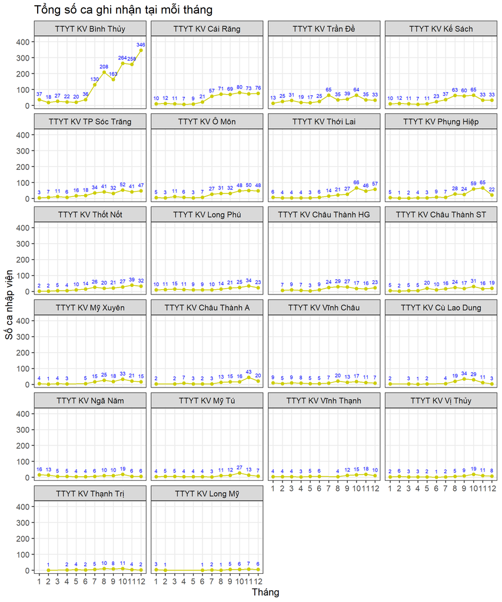

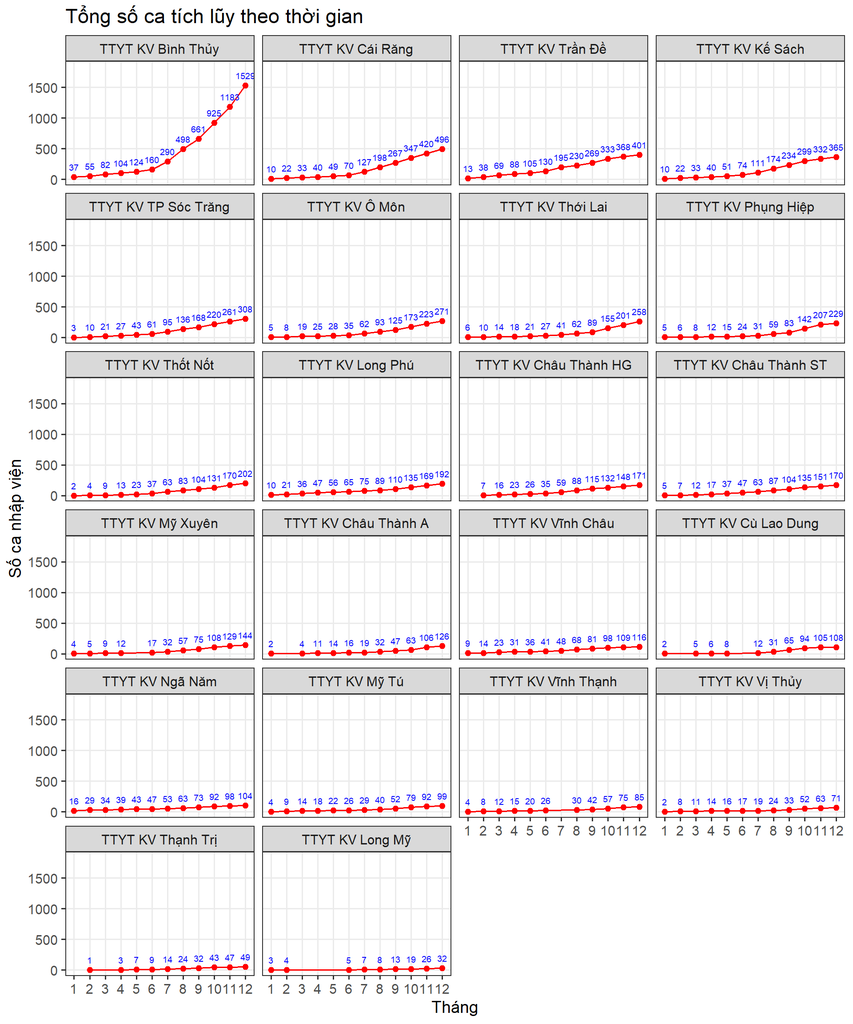

# 8 **TỔNG SỐ CA THEO TUẦN**

| TTYTKV | PHUONG_XA_MOI | WEEK | COUNT |
| --- | --- | --- | --- |
| TTYT KV Châu Thành ST | An Ninh | 1 | 1 |
| TTYT KV Bình Thủy | Bình Thủy | 1 | 1 |
| TTYT KV Bình Thủy | Cái Khế | 1 | 4 |
| TTYT KV Cái Răng | Cái Răng | 1 | 1 |
| TTYT KV Thới Lai | Cờ Đỏ | 1 | 1 |
| TTYT KV Cù Lao Dung | Cù Lao Dung | 1 | 1 |
| TTYT KV Long Phú | Đại Ngãi | 1 | 1 |
| TTYT KV Phụng Hiệp | Đại Thành | 1 | 1 |
| TTYT KV Thới Lai | Đông Thuận | 1 | 1 |
| TTYT KV Mỹ Xuyên | Hòa Tú | 1 | 1 |

[output cut: 2194 more lines]

VẼ ĐỒ THỊ

# 9 **ĐỒ THỊ THEO NGÀY**

## 9.1 TTYT KV Châu Thành ST

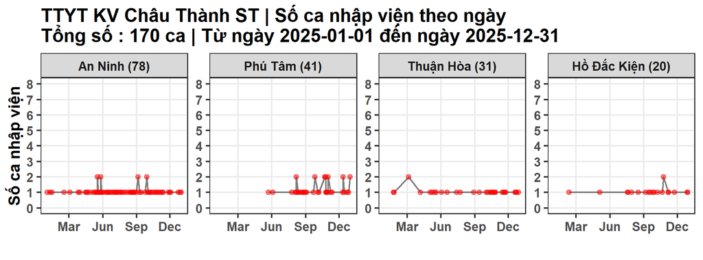

## 9.2 TTYT KV Bình Thủy

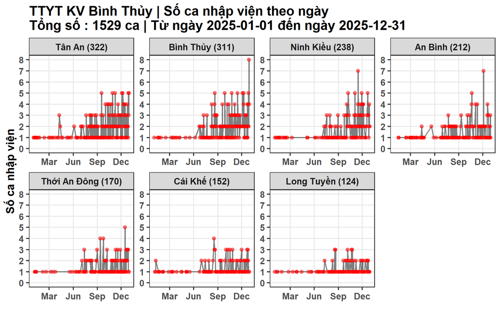

## 9.3 TTYT KV Long Phú

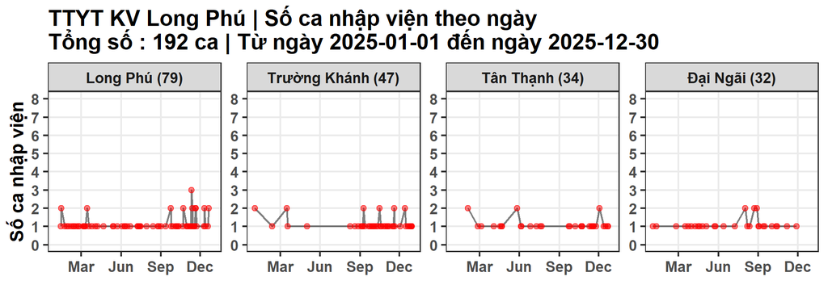

## 9.4 TTYT KV Thới Lai

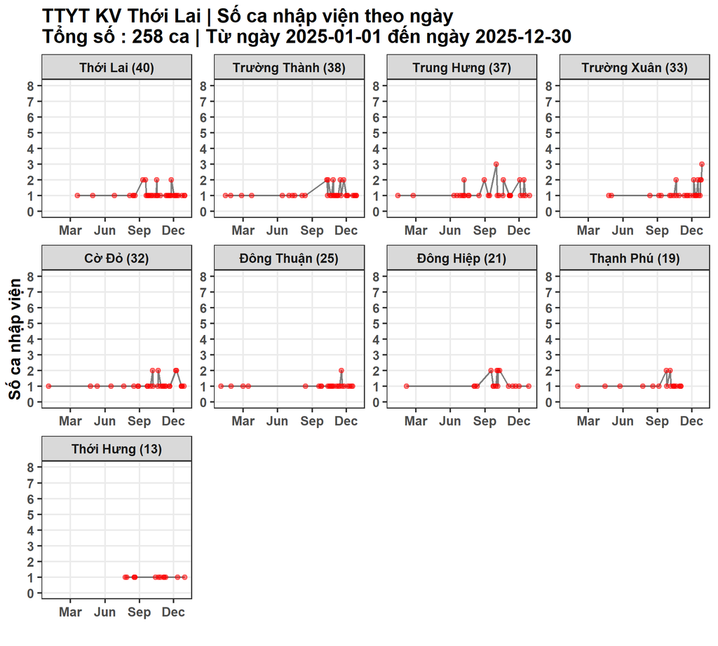

## 9.5 TTYT KV Kế Sách

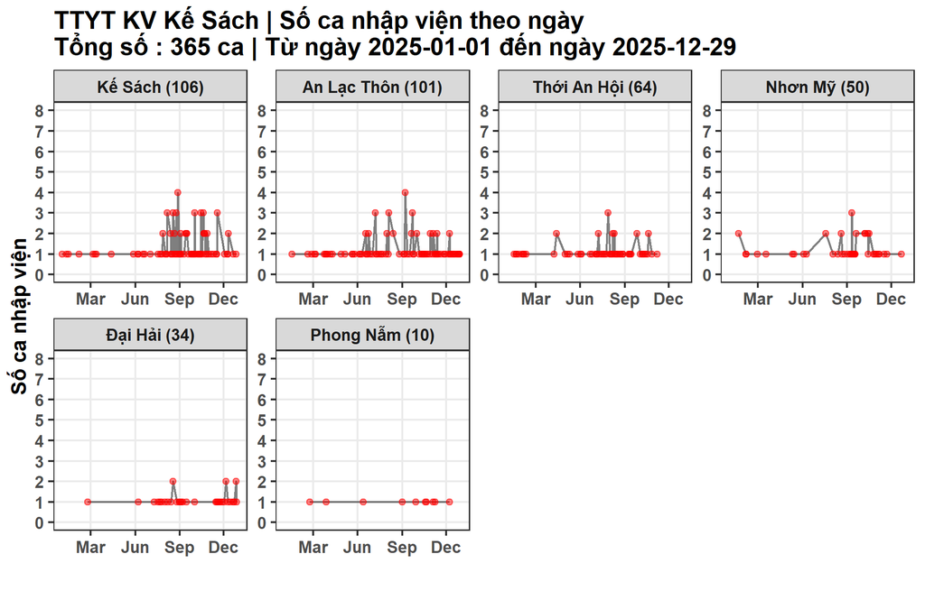

## 9.6 TTYT KV Trần Đề

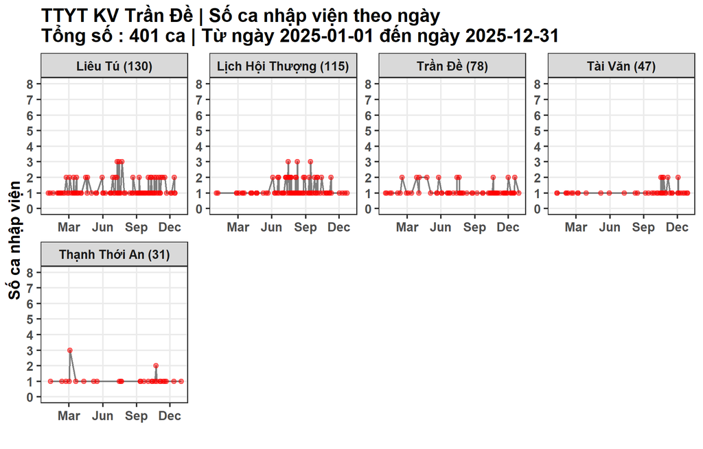

## 9.7 TTYT KV Ngã Năm

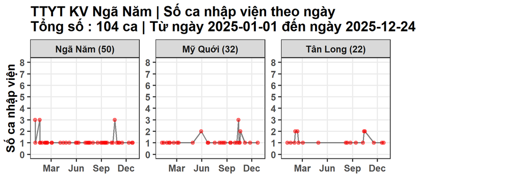

## 9.8 TTYT KV Cái Răng

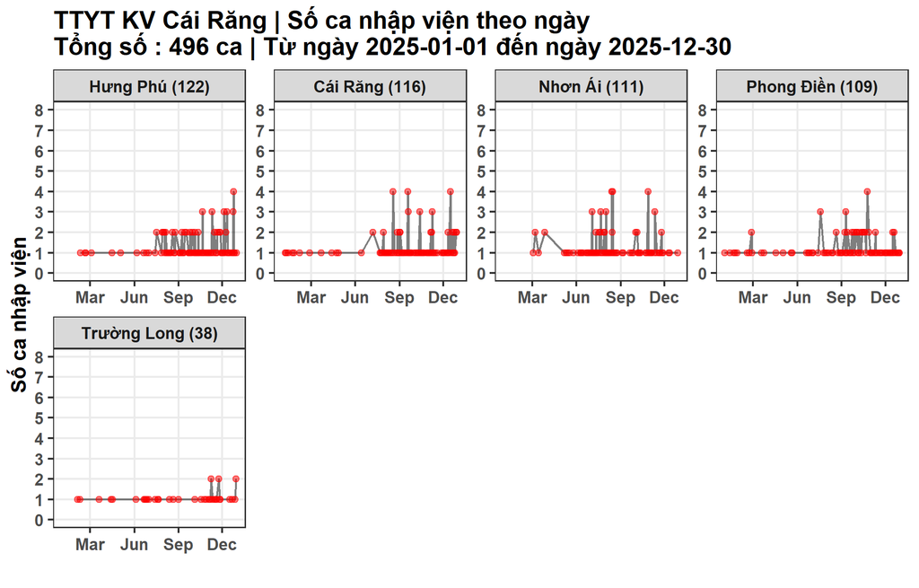

## 9.9 TTYT KV Ô Môn

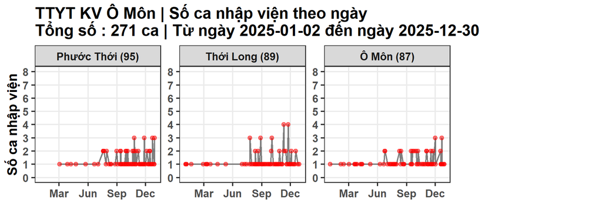

## 9.10 TTYT KV Thốt Nốt

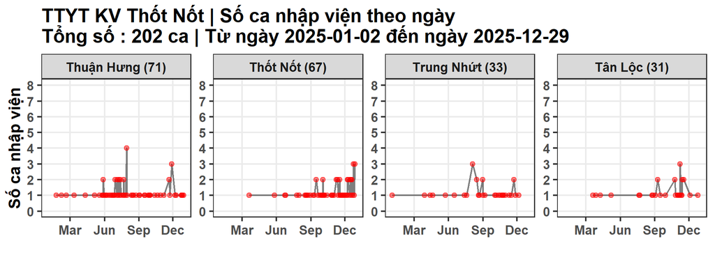

## 9.11 TTYT KV Mỹ Xuyên

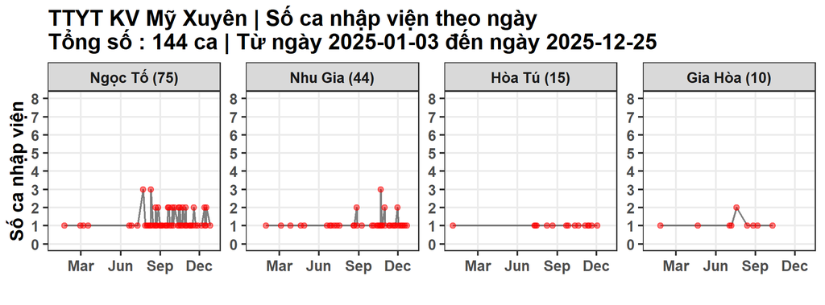

## 9.12 TTYT KV Vĩnh Châu

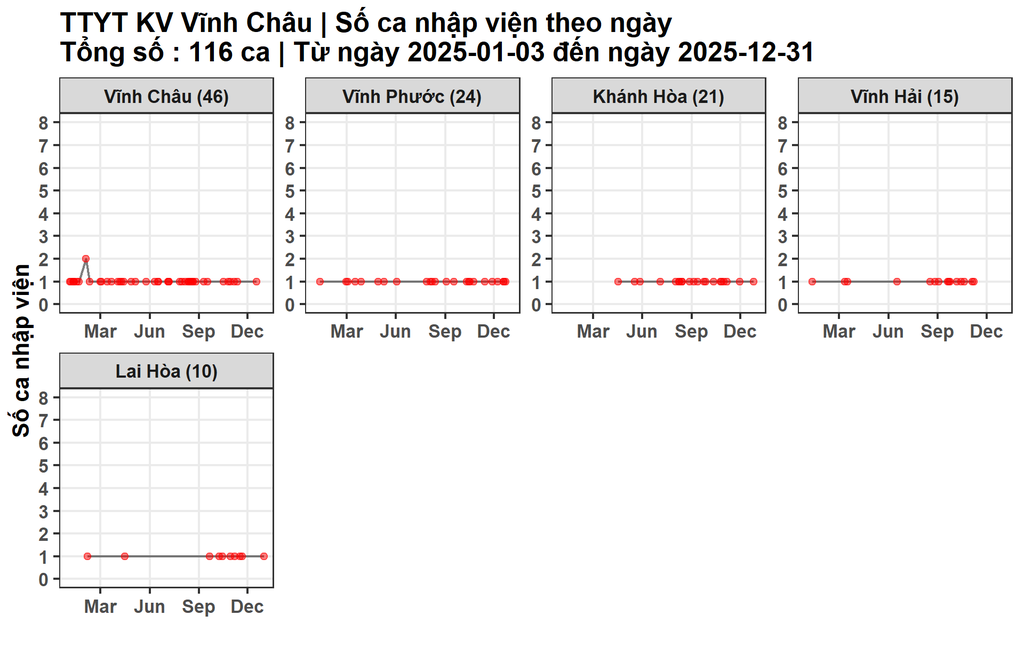

## 9.13 TTYT KV Vĩnh Thạnh

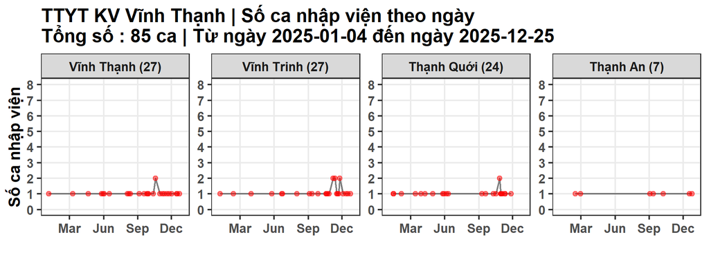

## 9.14 TTYT KV Long Mỹ

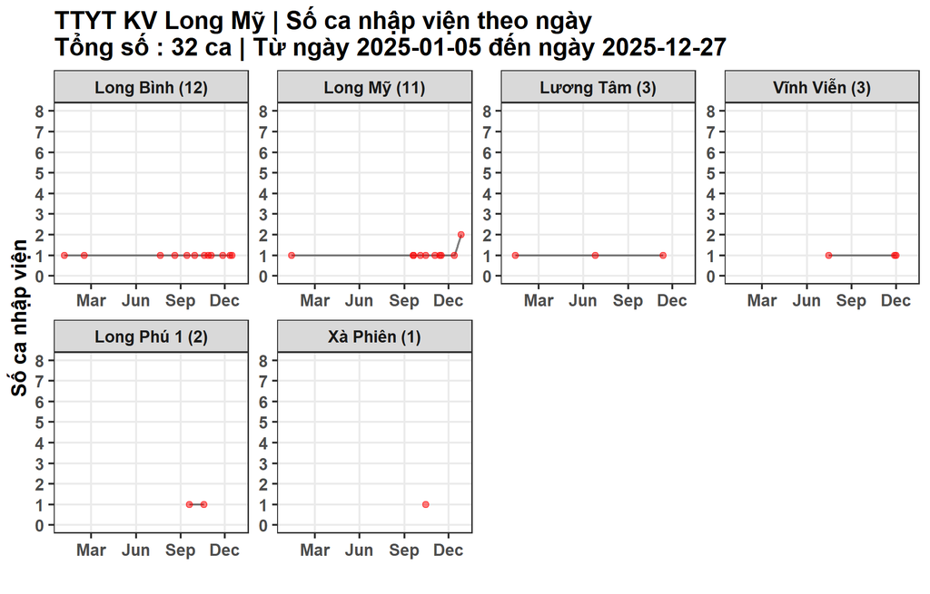

## 9.15 TTYT KV Cù Lao Dung

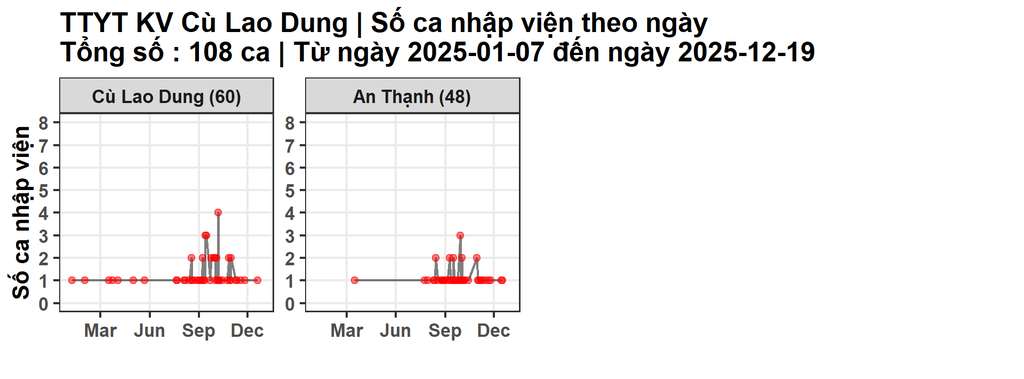

## 9.16 TTYT KV Phụng Hiệp

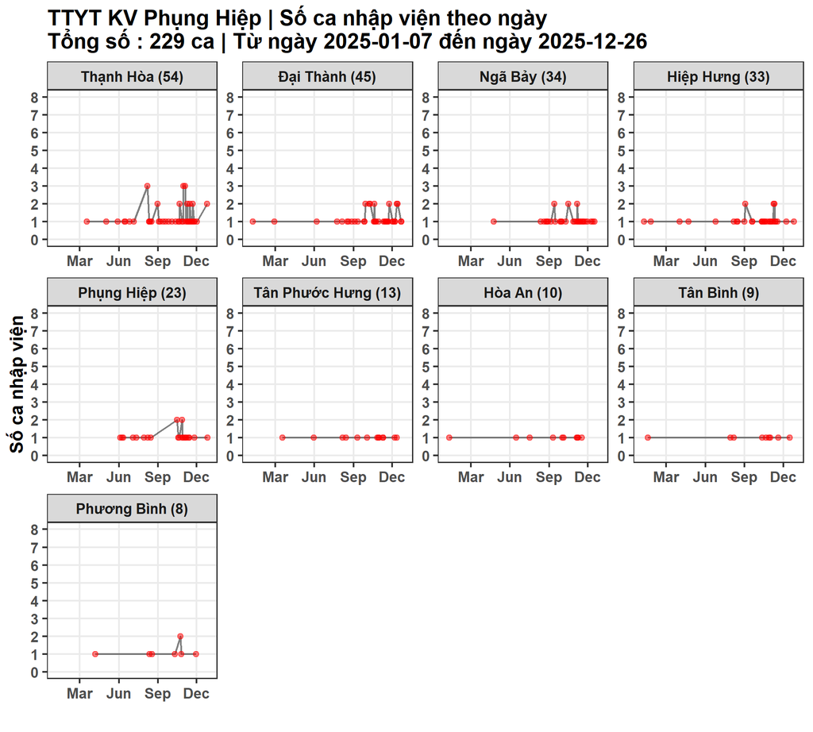

## 9.17 TTYT KV Mỹ Tú

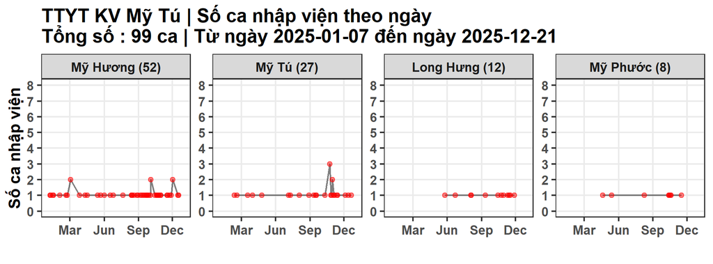

## 9.18 TTYT KV Vị Thủy

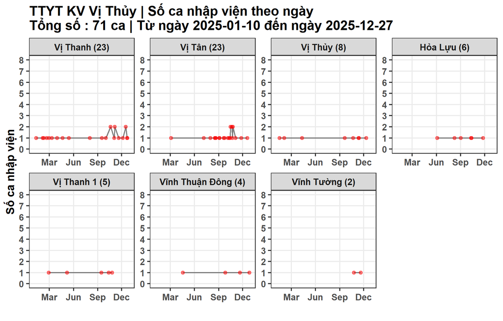

## 9.19 TTYT KV TP Sóc Trăng

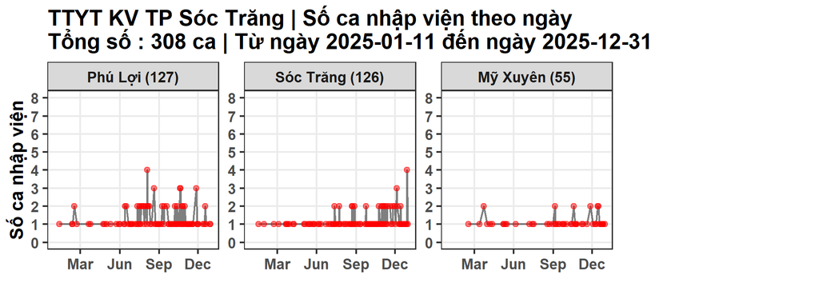

## 9.20 TTYT KV Châu Thành A

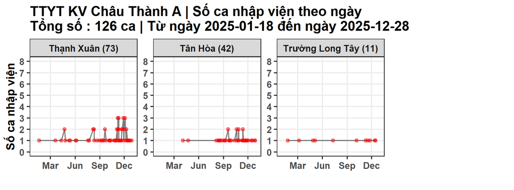

## 9.21 TTYT KV Châu Thành HG

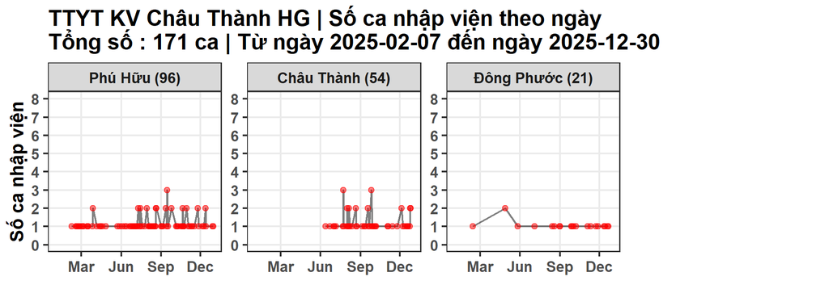

## 9.22 TTYT KV Thạnh Trị

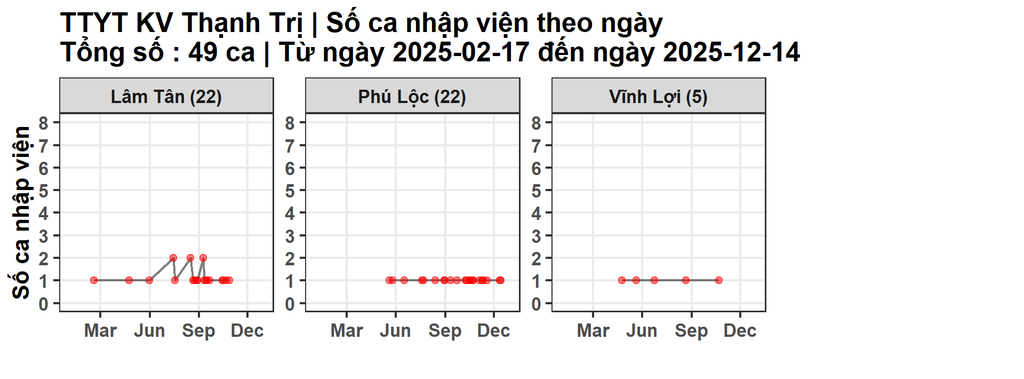

# 10 **ĐỒ THỊ THEO TUẦN**

## 10.1 TTYT KV Châu Thành ST

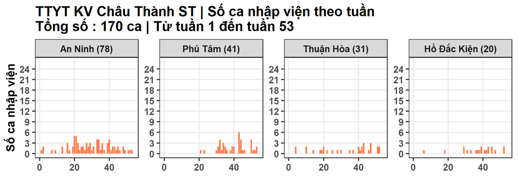

## 10.2 TTYT KV Bình Thủy

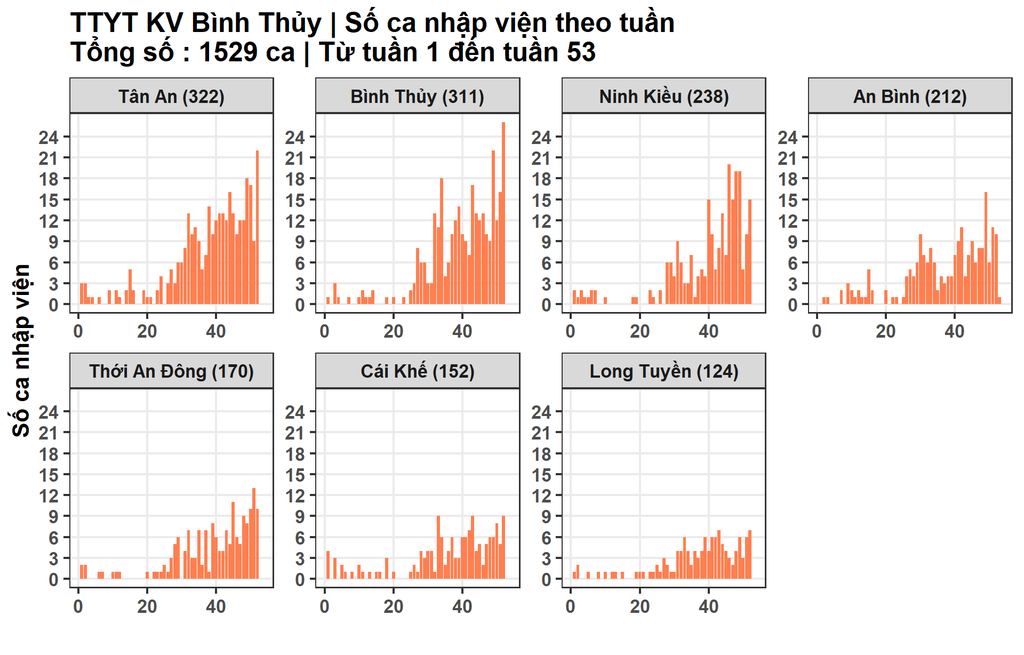

## 10.3 TTYT KV Cái Răng

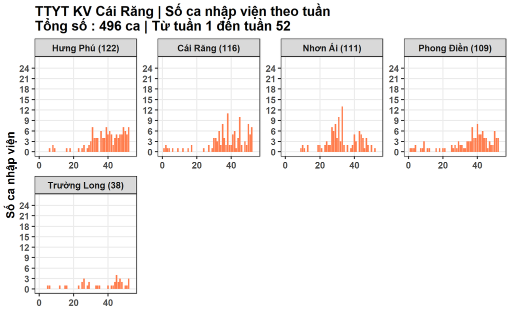

## 10.4 TTYT KV Thới Lai

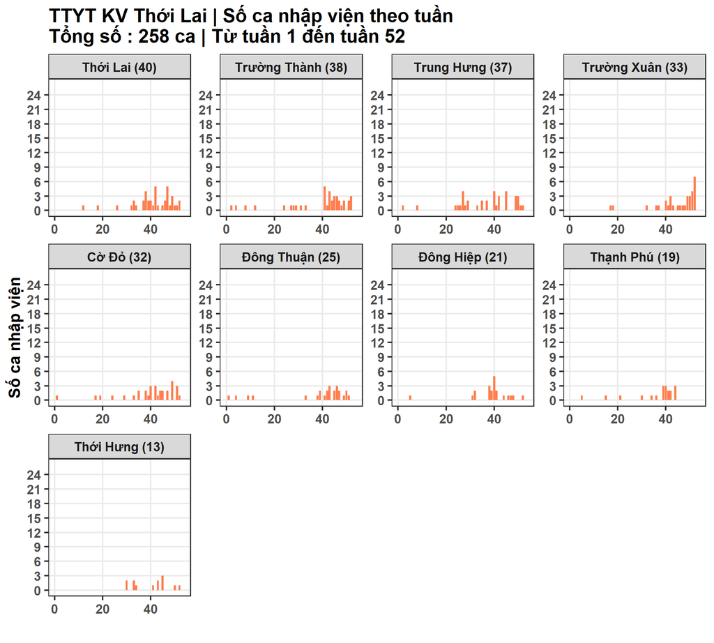

## 10.5 TTYT KV Cù Lao Dung

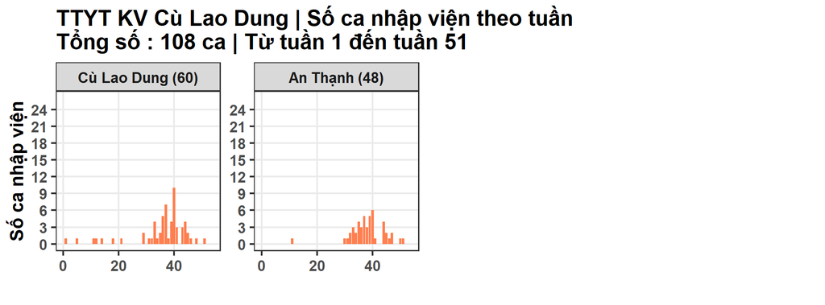

## 10.6 TTYT KV Long Phú

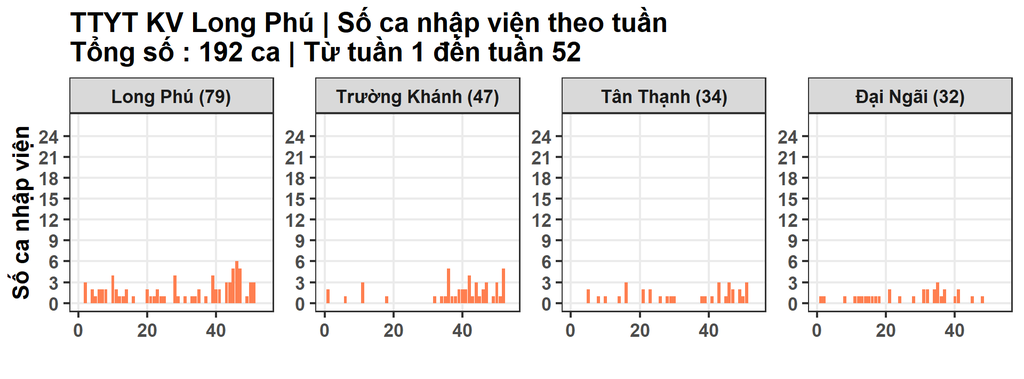